# Day 1: Species distribution models

Example of frequentist species distribution models

M. Grazia Pennino

# 1 Introduction

This practical section provides an introduction to species distribution modeling with R following the usual steps, such as: (1) compile locations of occurrence of a species; (2) extract values of environmental predictor variables at these locations from spatial databases; (3) use the environmental values to fit a model and to estimate the relationship among the species and its habitat; (4) extrapolate the identified relationship to predict the species distribution across a region of interest (and perhaps for a future or past climate); (5) validate the predictions. We will also see how produce psuedo-absence when are needed. SDM are implemented in R in many different ways. Here we focus on the functions in the “dismo” and the “raster” packages (but we also refer to other packages). Make sure you have the latest versions of these packages, and their dependencies, installed:

install.packages(c(“name_library1”, “name_library1”), dependencies = TRUE)

Then charge the libraries in a R section:

```r
library(dismo)
library(spdep)
library(Hmisc)
library(raster)
library(GGally)
library(ggplot2)
library(corrplot)
library(maptools)
library(sdmpredictors)
library(PresenceAbsence)
```

# 2 Species occurrence data and data cleaning

In this practical section we use data of the Argentine hake ($Merluccius$ $hubbsi$) species, which habitat is in the southwestern Atlantic Ocean, along the coast of Argentina. This dataset includes only-presence locations and were downloaded from the Ocean Biogeographic Information System (OBIS) (http://www.obis.org.au/cgi-bin/cs_map.pl). First we read the data in our workspace in R:

```r
# Read data from csv file
setwd("~/masterValencia/Day1/Practice")
data <- read.csv("data.csv")

#OR Rdata

load("data.RData")
```

This dataset has 3 columns. The first indicating the presence of the species (1) and the others two are coordinates of the locations in which the species was found present.

```r
dim(data)
```

```
## [1] 260   3
```

```r
head(data)
```

```
##   Species    Lat    Lon
## 1       1 -50.75 -62.25
## 2       1 -50.25 -68.25
## 3       1 -50.25 -62.75
## 4       1 -50.25 -62.75
## 5       1 -50.25 -61.75
## 6       1 -50.25 -61.25
```

Coordinates are typically expressed as longitude and latitude, but they could also be Easting and Northing with UTM or another planar coordinate reference system (map projection).  
Check always the format before analysis the data.

The second step is always to map the data in order to assure that the points are, at least roughly, in the right location.

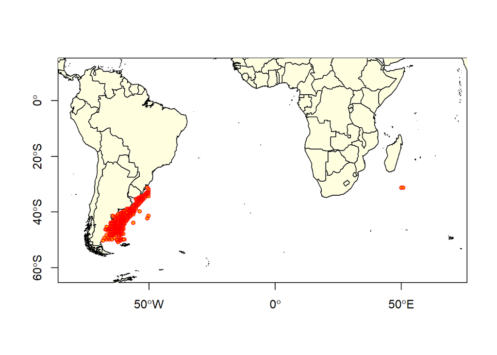

```r
data(wrld_simpl)
plot(wrld_simpl, xlim=c(-80,70), ylim=c(-60,10), axes=TRUE,col="light yellow")
points(data$Lon, data$Lat, col="orange", pch=20, cex=0.75)
points(data$Lon, data$Lat, col="red", cex=0.75)
```

There are a few records that map in the Indian Ocean, close to Madagascar. Any idea why that may have happened? It is a common mistake, missing minus signs. The coordinates are around (50.78, -31.06) but they should in Brazil around (-50.78, -31.06).

You can use the click() function to query the coordinates on the map, or the identify(data$Lon, data$Lat)function to know the position of the erroneous locations in the dataset. So the latitude is probably correct, and erroneously copied to the longitude. In this case we eliminate these observations from the dataset but you can correct them.

```r
data<-data[-c(259,260), ]
```

We plot again to be sure that we eliminate the data:

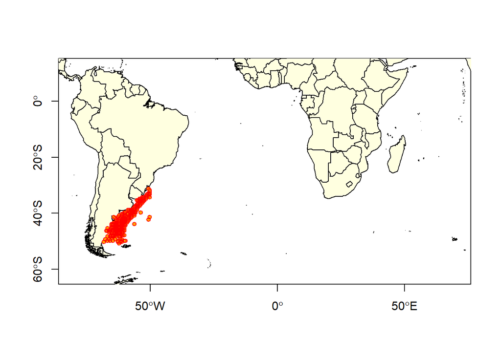

```r
plot(wrld_simpl, xlim=c(-80,70), ylim=c(-60,10), axes=TRUE,col="light yellow")
points(data$Lon, data$Lat, col="orange", pch=20, cex=0.75)
points(data$Lon, data$Lat, col="red", cex=0.75)
```

Another common error is that some observations are duplicated. A good practice is to check if there are duplicated observations and correct the error:

```r
dups2 <- duplicated(data[, c("Species","Lon","Lat")]);#which records are duplicates?
dups2
```

```
##   [1] FALSE FALSE FALSE  TRUE FALSE FALSE FALSE FALSE FALSE FALSE FALSE FALSE
##  [13] FALSE FALSE FALSE FALSE FALSE FALSE FALSE FALSE FALSE FALSE FALSE FALSE
##  [25] FALSE FALSE FALSE FALSE FALSE FALSE FALSE FALSE FALSE FALSE FALSE FALSE
##  [37] FALSE FALSE FALSE FALSE FALSE FALSE FALSE FALSE FALSE FALSE FALSE FALSE
##  [49] FALSE FALSE FALSE FALSE FALSE FALSE FALSE FALSE FALSE FALSE FALSE FALSE
##  [61] FALSE FALSE FALSE FALSE FALSE FALSE FALSE FALSE FALSE FALSE FALSE FALSE
##  [73] FALSE FALSE FALSE FALSE FALSE FALSE FALSE FALSE FALSE FALSE FALSE FALSE
##  [85] FALSE FALSE FALSE FALSE FALSE FALSE FALSE FALSE FALSE FALSE FALSE FALSE
##  [97] FALSE FALSE FALSE FALSE FALSE FALSE FALSE FALSE FALSE FALSE FALSE FALSE
## [109] FALSE FALSE FALSE FALSE FALSE FALSE FALSE FALSE FALSE FALSE FALSE FALSE
## [121] FALSE FALSE FALSE FALSE FALSE FALSE FALSE FALSE FALSE FALSE FALSE FALSE
## [133] FALSE FALSE FALSE FALSE FALSE FALSE FALSE FALSE FALSE FALSE FALSE FALSE
## [145] FALSE FALSE FALSE FALSE FALSE FALSE FALSE FALSE FALSE FALSE FALSE FALSE
## [157] FALSE FALSE FALSE FALSE FALSE FALSE FALSE FALSE FALSE FALSE FALSE FALSE
## [169] FALSE FALSE FALSE FALSE FALSE FALSE FALSE FALSE FALSE FALSE FALSE FALSE
## [181] FALSE FALSE FALSE FALSE FALSE FALSE FALSE FALSE FALSE FALSE FALSE FALSE
## [193] FALSE FALSE FALSE FALSE FALSE FALSE FALSE FALSE FALSE FALSE FALSE FALSE
## [205] FALSE FALSE FALSE FALSE FALSE FALSE FALSE FALSE FALSE FALSE FALSE FALSE
## [217] FALSE FALSE FALSE FALSE FALSE FALSE FALSE FALSE FALSE FALSE FALSE FALSE
## [229] FALSE FALSE FALSE FALSE FALSE FALSE FALSE FALSE FALSE FALSE FALSE FALSE
## [241] FALSE FALSE FALSE FALSE FALSE FALSE FALSE FALSE FALSE FALSE FALSE FALSE
## [253] FALSE FALSE FALSE FALSE FALSE FALSE
```

```r
sum(dups2) #Number of duplicates
```

```
## [1] 1
```

```r
data <- data[!dups2, ] #Remove duplicates
```

In this example we create the object “dups2” that identify the duplicate observations (TRUE or FALSE) and we eliminate the unique duplicated observation.

# 3 Environmental data

In SDMs predictor variables are typically organized as raster (grid) type files. Each predictor should be a $raster$ representing a variable of interest. For any particular study the layers should all have the same spatial extent, resolution and projection. Using the library $sdmpredictors$ we can easily check in R which variables you would like to use from different databases. Here we use some predictor from the Bio-ORCALE database that offers an array of geophysical, biotic and climate data at a spatial resolution 5 arcmin (9.2 km) in the ESRI ascii format.

```r
list_layers(c("Bio-ORACLE","MARSPEC"))$layer_code #Get the file names and list layer codes for Bio-ORACLE and MARSPEC
```

```
##   [1] "BO_calcite"                       "BO_chlomax"
##   [3] "BO_chlomean"                      "BO_chlomin"
##   [5] "BO_chlorange"                     "BO_cloudmean"
##   [7] "BO_cloudmin"                      "BO_damax"
##   [9] "BO_damean"                        "BO_damin"
##  [11] "BO_dissox"                        "BO_nitrate"
##  [13] "BO_parmax"                        "BO_parmean"
##  [15] "BO_ph"                            "BO_phosphate"
##  [17] "BO_salinity"                      "BO_silicate"
##  [19] "BO_sstmax"                        "BO_sstmean"
##  [21] "BO_sstmin"                        "BO_sstrange"
##  [23] "BO_bathymin"                      "BO_bathymax"
##  [25] "BO_bathymean"                     "MS_bathy_5m"
##  [27] "MS_biogeo01_aspect_EW_5m"         "MS_biogeo02_aspect_NS_5m"
##  [29] "MS_biogeo03_plan_curvature_5m"    "MS_biogeo04_profile_curvature_5m"
```

[output cut: 465 more lines]

```r
setwd("~/masterValencia/Day1/Practice/predictors")#Get the file from PC
files<-(list.files(".", full.names=T, pattern=".tif"))#change directory
predictors <- stack(files)#bioclimatic variables

#OR read directly in the workspace
#predictors<- load_layers(c("BO_calcite","BO_chlomean","BO_nitrate","BO_ph","BO_phosphate", #"BO_silicate","BO_salinity","BO_sstmean"), datadir = ".")
```

This database includes eight different climatic variables of the entire world. Here we make a list of files, we create a rasterStack object (predictors) from these, we name each layer, and finally we plot them.

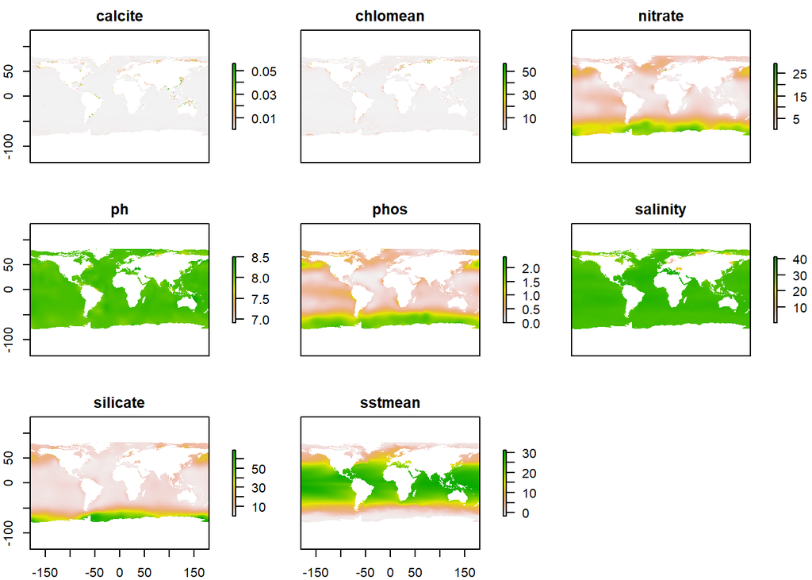

```r
names(predictors) <-c("calcite","chlomean","nitrate","ph","phos","salinity","silicate","sstmean")
plot(predictors)
```

As we have to work just with the South America we can cut the predictors just for the extension of the studied area:

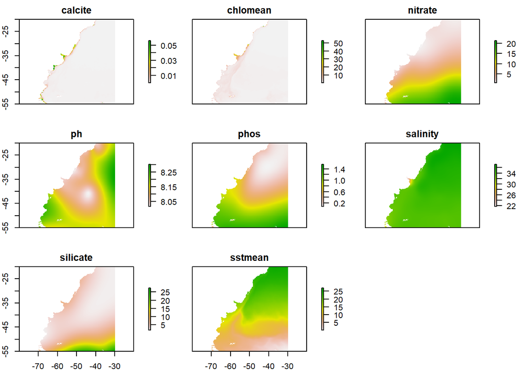

```r
ext<-extent(-70,-30,-55,-20)
predictors<-crop(predictors, ext)
plot(predictors)
```

We can also make a plot of a single layer in a RasterStack, and plot some additional data on top of it.

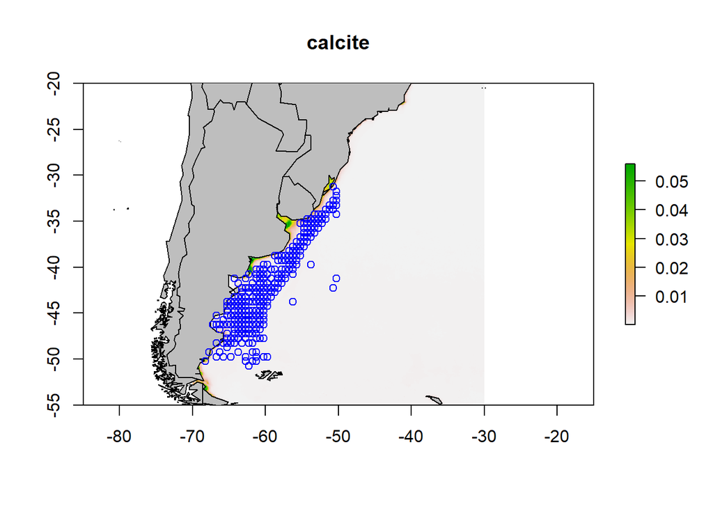

```r
par(mfrow=c(1,1))
plot(predictors, 1)
plot(wrld_simpl, col = "grey", add =TRUE)
points(data$Lon, data$Lat, col = "blue")
```

# 4 Standardize predictors

It is always a good practice to standardize the environmental variables as they have a very different unit scale. The standardization is done resting the mean and dividing for the standard deviation.

```r
predictors2<-scale(predictors)
round(apply(values(predictors2), 2, summary), 4)
```

```
##            calcite   chlomean    nitrate         ph       phos   salinity
## Min.       -0.1715    -0.3973    -1.2647    -2.0772    -1.3630   -11.1808
## 1st Qu.    -0.1601    -0.3124    -0.9541    -0.8660    -1.0213    -0.6846
## Median     -0.1281    -0.1892    -0.2048     0.1061    -0.0053    -0.2484
## Mean        0.0000     0.0000     0.0000     0.0000     0.0000     0.0000
## 3rd Qu.    -0.1017    -0.0541     0.8182     0.6320     0.9241     0.7640
## Max.       16.0918    42.7719     2.1875     2.5283     1.9775     2.0750
## NA's    62201.0000 62201.0000 62201.0000 62201.0000 62201.0000 62201.0000
##           silicate    sstmean
## Min.       -0.8088    -1.9873
## 1st Qu.    -0.6425    -0.8188
## Median     -0.4024    -0.0767
## Mean        0.0000     0.0000
## 3rd Qu.     0.1322     0.8617
## Max.        4.3904     1.9236
## NA's    62201.0000 62201.0000
```

# 5 Extracting environmental values from rasters

We now have a set of predictor variables and presence points. The next step is to extract the values of the predictors at the presence locations of the points. This is a very straightforward thing to do using the $extract()$ function from the $raster$ package.

```r
coords1=cbind(data$Lon, data$Lat)
colnames(coords1)<-c("x","y")
presvals <- extract(predictors2, coords1)
head(presvals)
```

```
##          calcite  chlomean   nitrate        ph     phos   salinity   silicate
## [1,] -0.09121268 0.3326481 0.7327162 1.0462856 1.219693 -0.9018182 -0.1873017
## [2,]  2.33260386 1.1455965 0.2385030 1.6199836 1.244565 -1.9617107 -0.6565485
## [3,] -0.07841749 0.6009545 0.6215182 1.1418944 1.190564 -0.9739477 -0.3030770
## [4,] -0.09295748 0.4116011 0.6834618 1.0462856 1.171517 -0.8755133 -0.2297262
## [5,] -0.09848268 0.6083146 0.7125135 0.9984737 1.160090 -0.8339324 -0.1918614
## [6,] -0.07376469 0.7923152 0.7156858 0.8550530 1.080768 -0.7456787 -0.1522122
##         sstmean
## [1,] -0.8223744
## [2,] -0.7570219
## [3,] -0.7730002
## [4,] -0.8016459
## [5,] -0.8226622
## [6,] -0.7869631
```

# 6 Absence and background points

Some of the early species distribution model algorithms, such as BIOCLIM, only use presence data in the modeling process. Other methods also use absence data. One example is the logistic regression that is often implemented in a generalized linear modeling (GLM) framework. If you have a large dataset with presence/absence from a well-designed survey, you should use a method that can use these data (i.e. do not use a modeling method that only considers presence data). If you only have presence data, you can still use a method that needs absence data, by substituting absence data with background data. Background data establishes the environmental domain of the study, whilst presence data should establish under which conditions a species is more likely to be present than on average. In the example below, we use the rasterStack object “predictors” as background. Using the randomPoints() function we sample 200 locations from the background that will be used as absence locations.

```r
set.seed(500)
backgr <- randomPoints(predictors2, 200)
backgr <-as.data.frame(backgr)
head(backgr)
```

```
##           x         y
## 1 -65.29167 -51.62500
## 2 -37.62500 -27.54167
## 3 -52.95833 -41.79167
## 4 -38.12500 -29.20833
## 5 -35.62500 -29.79167
## 6 -59.29167 -44.87500
```

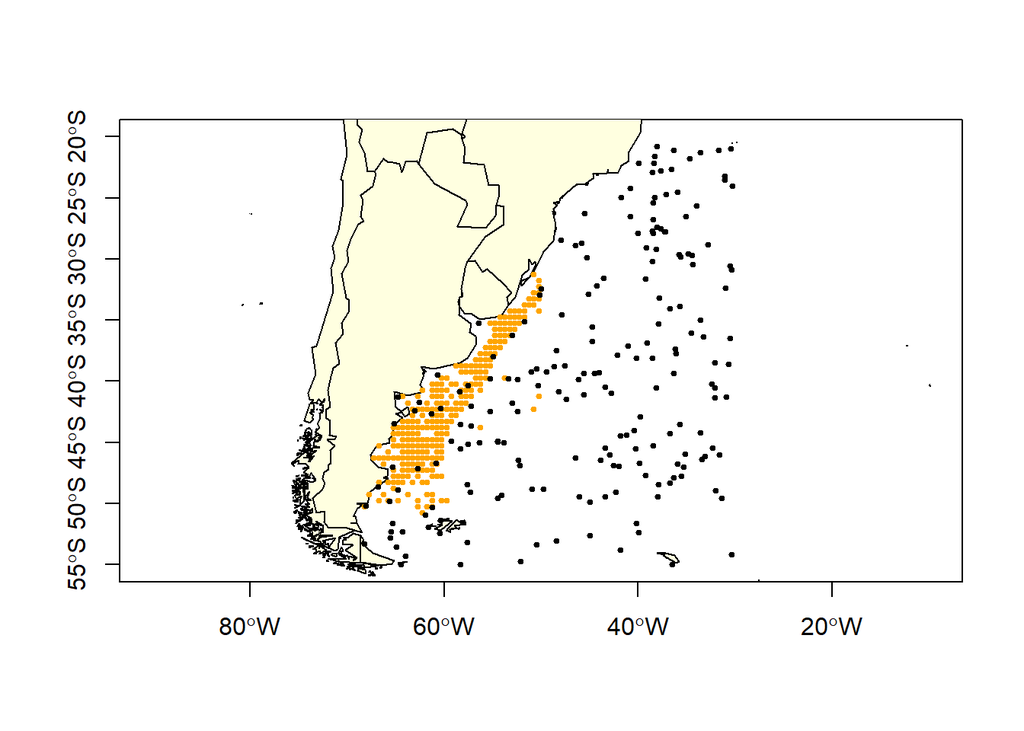

```r
plot(wrld_simpl, xlim=c(-70,-30), ylim=c(-55,-20), axes=TRUE,col="light yellow")
points(data$Lon, data$Lat, col="orange", pch=20, cex=0.75)
points(backgr, col="black", pch=20, cex=0.75)
```

Now we repeat the sampling, but limit the area of sampling using a spatial extent:

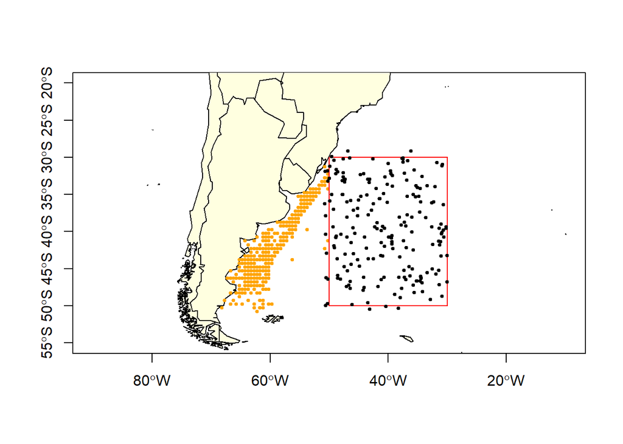

```r
e <- extent(-50, -30, -50, -30)
bg2 <- randomPoints(predictors2, 200, ext=e)

plot(wrld_simpl, xlim=c(-70,-30), ylim=c(-55,-20), axes=TRUE,col="light yellow")
points(data$Lon, data$Lat, col="orange", pch=20, cex=0.75)
plot(e, add=TRUE, col="red")
points(bg2, col="black", pch=20, cex=0.75)
```

Then we extract the environmental values for these locations, as we did for the presence locations:

```r
absvals <- extract(predictors2, backgr)
head(absvals)
```

```
##          calcite    chlomean      nitrate         ph       phos   salinity
## [1,] -0.06213269  0.55679438  0.667266310  1.1100248  1.3034962 -1.2650170
## [2,] -0.16798383 -0.37993622 -1.079843914  0.6478932 -1.3419051  1.3588304
## [3,] -0.12378226 -0.01862585 -0.332847411 -1.0891277 -0.1841219 -0.2000324
## [4,] -0.16769303 -0.37458347 -1.037268120  0.7275595 -1.3466106  1.1432898
## [5,] -0.16216784 -0.37859803 -0.979999513  1.2853302 -1.2930573  1.0321237
## [6,] -0.10633427 -0.14374628  0.008092842  0.4247758  0.6238839 -0.7422830
##        silicate    sstmean
## [1,] -0.2703665 -0.8613842
## [2,] -0.7098765  1.3201468
## [3,] -0.4908154  0.2113159
## [4,] -0.7245467  1.1839722
## [5,] -0.7673677  1.1333026
## [6,] -0.4271786 -0.7862434
```

We combine these values with the ones of the presence dataset and we generate a new dataset with presence/absence of the species and their relative environmental values (as shown in the map below, presence are in orange and absences in black).

```r
coords<-as.data.frame(rbind(coords1,backgr))#generate a unique coordinates vector
pb <- c(rep(1, nrow(presvals)), rep(0, nrow(absvals)));pb
```

```
##   [1] 1 1 1 1 1 1 1 1 1 1 1 1 1 1 1 1 1 1 1 1 1 1 1 1 1 1 1 1 1 1 1 1 1 1 1 1 1
##  [38] 1 1 1 1 1 1 1 1 1 1 1 1 1 1 1 1 1 1 1 1 1 1 1 1 1 1 1 1 1 1 1 1 1 1 1 1 1
##  [75] 1 1 1 1 1 1 1 1 1 1 1 1 1 1 1 1 1 1 1 1 1 1 1 1 1 1 1 1 1 1 1 1 1 1 1 1 1
## [112] 1 1 1 1 1 1 1 1 1 1 1 1 1 1 1 1 1 1 1 1 1 1 1 1 1 1 1 1 1 1 1 1 1 1 1 1 1
## [149] 1 1 1 1 1 1 1 1 1 1 1 1 1 1 1 1 1 1 1 1 1 1 1 1 1 1 1 1 1 1 1 1 1 1 1 1 1
## [186] 1 1 1 1 1 1 1 1 1 1 1 1 1 1 1 1 1 1 1 1 1 1 1 1 1 1 1 1 1 1 1 1 1 1 1 1 1
## [223] 1 1 1 1 1 1 1 1 1 1 1 1 1 1 1 1 1 1 1 1 1 1 1 1 1 1 1 1 1 1 1 1 1 1 1 0 0
## [260] 0 0 0 0 0 0 0 0 0 0 0 0 0 0 0 0 0 0 0 0 0 0 0 0 0 0 0 0 0 0 0 0 0 0 0 0 0
## [297] 0 0 0 0 0 0 0 0 0 0 0 0 0 0 0 0 0 0 0 0 0 0 0 0 0 0 0 0 0 0 0 0 0 0 0 0 0
## [334] 0 0 0 0 0 0 0 0 0 0 0 0 0 0 0 0 0 0 0 0 0 0 0 0 0 0 0 0 0 0 0 0 0 0 0 0 0
## [371] 0 0 0 0 0 0 0 0 0 0 0 0 0 0 0 0 0 0 0 0 0 0 0 0 0 0 0 0 0 0 0 0 0 0 0 0 0
## [408] 0 0 0 0 0 0 0 0 0 0 0 0 0 0 0 0 0 0 0 0 0 0 0 0 0 0 0 0 0 0 0 0 0 0 0 0 0
## [445] 0 0 0 0 0 0 0 0 0 0 0 0 0
```

```r
sdmdata <- data.frame(cbind(pb, rbind(presvals, absvals), coords))
head(sdmdata)
```

```
##   pb     calcite  chlomean   nitrate        ph     phos   salinity   silicate
## 1  1 -0.09121268 0.3326481 0.7327162 1.0462856 1.219693 -0.9018182 -0.1873017
## 2  1  2.33260386 1.1455965 0.2385030 1.6199836 1.244565 -1.9617107 -0.6565485
## 3  1 -0.07841749 0.6009545 0.6215182 1.1418944 1.190564 -0.9739477 -0.3030770
## 4  1 -0.09295748 0.4116011 0.6834618 1.0462856 1.171517 -0.8755133 -0.2297262
## 5  1 -0.09848268 0.6083146 0.7125135 0.9984737 1.160090 -0.8339324 -0.1918614
## 6  1 -0.07376469 0.7923152 0.7156858 0.8550530 1.080768 -0.7456787 -0.1522122
##      sstmean      x      y
## 1 -0.8223744 -62.25 -50.75
## 2 -0.7570219 -68.25 -50.25
## 3 -0.7730002 -62.75 -50.25
## 4 -0.8016459 -61.75 -50.25
## 5 -0.8226622 -61.25 -50.25
## 6 -0.7869631 -59.75 -49.75
```

We now check if there are NAs and we eliminate them:

```r
summary(sdmdata)
```

```
##        pb            calcite            chlomean          nitrate
##  Min.   :0.0000   Min.   :-0.17147   Min.   :-0.3953   Min.   :-1.2356
##  1st Qu.:0.0000   1st Qu.:-0.13360   1st Qu.:-0.1826   1st Qu.:-0.8434
##  Median :1.0000   Median :-0.08147   Median : 0.3889   Median :-0.4502
##  Mean   :0.5624   Mean   : 0.07851   Mean   : 0.3782   Mean   :-0.2970
##  3rd Qu.:1.0000   3rd Qu.:-0.03909   3rd Qu.: 0.7371   3rd Qu.: 0.1113
##  Max.   :1.0000   Max.   :15.61489   Max.   : 8.3377   Max.   : 2.1369
##                   NA's   :1          NA's   :1         NA's   :1
##        ph                phos            salinity          silicate
##  Min.   :-1.99748   Min.   :-1.3562   Min.   :-5.7778   Min.   :-0.7759
##  1st Qu.:-1.04132   1st Qu.:-0.3691   1st Qu.:-1.0219   1st Qu.:-0.5882
##  Median : 0.20167   Median : 0.3764   Median :-0.8144   Median :-0.4308
##  Mean   : 0.08649   Mean   : 0.1992   Mean   :-0.4899   Mean   :-0.3026
##  3rd Qu.: 1.01840   3rd Qu.: 0.8232   3rd Qu.:-0.2796   3rd Qu.:-0.1919
##  Max.   : 2.40084   Max.   : 1.9069   Max.   : 1.9673   Max.   : 3.8839
##  NA's   :1          NA's   :1         NA's   :1         NA's   :1
##     sstmean               x                y
##  Min.   :-1.95179   Min.   :-68.25   Min.   :-54.96
##  1st Qu.:-0.54934   1st Qu.:-61.75   1st Qu.:-46.25
##  Median :-0.18317   Median :-56.75   Median :-42.25
##  Mean   :-0.02117   Mean   :-53.36   Mean   :-41.16
##  3rd Qu.: 0.46171   3rd Qu.:-44.96   3rd Qu.:-37.25
##  Max.   : 1.75026   Max.   :-30.29   Max.   :-20.79
##  NA's   :1
```

```r
to.remove <- which(!complete.cases(sdmdata))
sdmdata <- sdmdata[-to.remove,]
summary(sdmdata)
```

```
##        pb            calcite            chlomean          nitrate
##  Min.   :0.0000   Min.   :-0.17147   Min.   :-0.3953   Min.   :-1.2356
##  1st Qu.:0.0000   1st Qu.:-0.13360   1st Qu.:-0.1826   1st Qu.:-0.8434
##  Median :1.0000   Median :-0.08147   Median : 0.3889   Median :-0.4502
##  Mean   :0.5614   Mean   : 0.07851   Mean   : 0.3782   Mean   :-0.2970
##  3rd Qu.:1.0000   3rd Qu.:-0.03909   3rd Qu.: 0.7371   3rd Qu.: 0.1113
##  Max.   :1.0000   Max.   :15.61489   Max.   : 8.3377   Max.   : 2.1369
##        ph                phos            salinity          silicate
##  Min.   :-1.99748   Min.   :-1.3562   Min.   :-5.7778   Min.   :-0.7759
##  1st Qu.:-1.04132   1st Qu.:-0.3691   1st Qu.:-1.0219   1st Qu.:-0.5882
##  Median : 0.20167   Median : 0.3764   Median :-0.8144   Median :-0.4308
##  Mean   : 0.08649   Mean   : 0.1992   Mean   :-0.4899   Mean   :-0.3026
##  3rd Qu.: 1.01840   3rd Qu.: 0.8232   3rd Qu.:-0.2796   3rd Qu.:-0.1919
##  Max.   : 2.40084   Max.   : 1.9069   Max.   : 1.9673   Max.   : 3.8839
##     sstmean               x                y
##  Min.   :-1.95179   Min.   :-68.25   Min.   :-54.96
##  1st Qu.:-0.54934   1st Qu.:-61.75   1st Qu.:-46.25
##  Median :-0.18317   Median :-56.75   Median :-42.25
##  Mean   :-0.02117   Mean   :-53.33   Mean   :-41.14
##  3rd Qu.: 0.46171   3rd Qu.:-44.96   3rd Qu.:-37.25
##  Max.   : 1.75026   Max.   :-30.29   Max.   :-20.79
```

# 7 Exploration of the dataset

Before run any SDMs a good practice is to perform some explanatory analysis on the collinearity, correlation and linearity of the explicative variables with respect to the response one. We can use different approach. One for example is to compute a correlation matrix and plot it with the corrplot() function also assessing which correlation are significant or not

## 7.1 Step 1: Check correlation among explicative variables. Variables highly correlated can NOT be used together in the model.

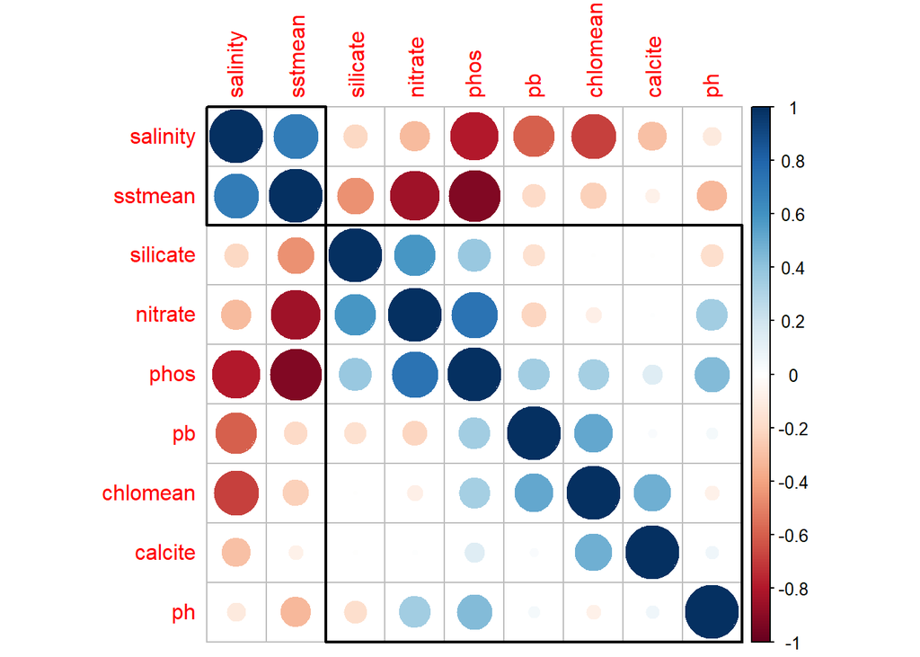

```r
M=cor(sdmdata[,c(1:9)])
testRes = cor.mtest(sdmdata[,c(1:9)], conf.level = 0.95)

#specialized the insignificant value according to the significant level
corrplot(M,  order = 'hclust', addrect = 2)
```

```r
#If using 'hclust', corrplot() can draw rectangles around the plot of correlation matrix based on the results of hierarchical clustering
```

## 7.2 Step 2: Check if the response variables and the explicative variables have linear relationship

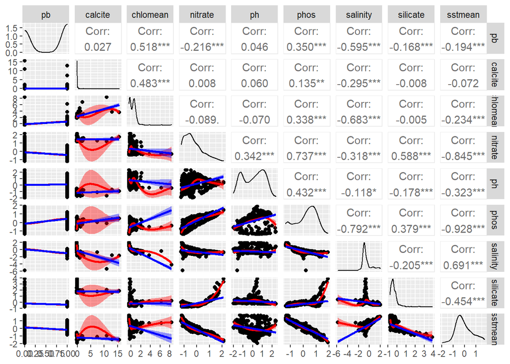

```r
my_fn <- function(data, mapping, ...){
  p <- ggplot(data = data, mapping = mapping) +
    geom_point() +
    geom_smooth(method=loess, fill="red", color="red", ...) +
    geom_smooth(method=lm, fill="blue", color="blue", ...)
  p
}

g = ggpairs(sdmdata[,c(1:9)], lower = list(continuous = my_fn))
g
```

## 7.3 Step 3: Check multicollinearity among variables

Collinearity among explanatory variables, can complicate or prevent the identification of an optimal set of explanatory variables for a statistical model. Here, we use a simple approach to identify collinearity among explanatory variables using the variance inflation factors (VIF). VIF calculations are straightforward and easily comprehensible; the higher the value, the higher the collinearity. A VIF is calculated for each explanatory variable and those with high values are removed. The definition of ‘high’ is somewhat arbitrary but values higher than 5 have to be removed.

```r
setwd("~/masterValencia/Day1/Practice")
source("HighstatLib.r")
corvif(sdmdata[,c(2:9)])
```

```
## Correlations of the variables
##
##               calcite     chlomean      nitrate          ph       phos
## calcite   1.000000000  0.482969762  0.008286698  0.06016805  0.1350706
## chlomean  0.482969762  1.000000000 -0.089114110 -0.07018784  0.3382202
## nitrate   0.008286698 -0.089114110  1.000000000  0.34225908  0.7373327
## ph        0.060168050 -0.070187836  0.342259078  1.00000000  0.4316531
## phos      0.135070616  0.338220183  0.737332655  0.43165308  1.0000000
## salinity -0.294512479 -0.683122398 -0.318229953 -0.11848287 -0.7917229
## silicate -0.007759896 -0.005309416  0.587973148 -0.17784696  0.3786664
## sstmean  -0.071901600 -0.233798836 -0.844598147 -0.32282825 -0.9276546
##            salinity     silicate    sstmean
## calcite  -0.2945125 -0.007759896 -0.0719016
## chlomean -0.6831224 -0.005309416 -0.2337988
## nitrate  -0.3182300  0.587973148 -0.8445981
## ph       -0.1184829 -0.177846959 -0.3228282
## phos     -0.7917229  0.378666354 -0.9276546
## salinity  1.0000000 -0.205330029  0.6909250
## silicate -0.2053300  1.000000000 -0.4537960
## sstmean   0.6909250 -0.453796034  1.0000000
##
##
## Variance inflation factors
##
##               GVIF
## calcite   1.431042
## chlomean  2.840648
## nitrate   9.722361
## ph        2.242942
## phos     17.152630
## salinity  9.282842
## silicate  2.161189
## sstmean  15.811394
```

```r
corvif(sdmdata[,c(2,3,4,5,8)])
```

```
## Correlations of the variables
##
##               calcite     chlomean      nitrate          ph     silicate
## calcite   1.000000000  0.482969762  0.008286698  0.06016805 -0.007759896
## chlomean  0.482969762  1.000000000 -0.089114110 -0.07018784 -0.005309416
## nitrate   0.008286698 -0.089114110  1.000000000  0.34225908  0.587973148
## ph        0.060168050 -0.070187836  0.342259078  1.00000000 -0.177846959
## silicate -0.007759896 -0.005309416  0.587973148 -0.17784696  1.000000000
##
##
## Variance inflation factors
##
##              GVIF
## calcite  1.320312
## chlomean 1.330301
## nitrate  2.246757
## ph       1.517596
## silicate 2.038354
```

# 8 Generalized Linear Models (GLMs)

Now we have a dataset of presence/absence so we can use different models. Here we use a generalized linear model (GLM), which is a generalization of ordinary least squares regression. Models are fit using maximum likelihood and by allowing the linear model to be related to the response variable via a link function. Specifically, we use a binomial distribution (as our response variables is binary 1 and 0) with the common logit link function. In R, GLM is implemented in the glm() function, and the link function and error distribution are specified with the “family” argument (family = binomial(link = “logit”)).

```r
m1<- glm(pb ~ calcite+chlomean+nitrate+ph+salinity, data=sdmdata,family="binomial")
summary(m1)
```

```
##
## Call:
## glm(formula = pb ~ calcite + chlomean + nitrate + ph + salinity,
##     family = "binomial", data = sdmdata)
##
## Deviance Residuals:
##     Min       1Q   Median       3Q      Max
## -6.1736  -0.3286   0.2720   0.4329   2.5822
##
## Coefficients:
##             Estimate Std. Error z value Pr(>|z|)
## (Intercept)  -2.1776     0.2803  -7.768 7.95e-15 ***
## calcite      -0.7276     0.2382  -3.054  0.00226 **
## chlomean      1.4458     0.5149   2.808  0.00499 **
## nitrate      -2.2402     0.3249  -6.895 5.39e-12 ***
## ph            0.3281     0.1813   1.809  0.07042 .
## salinity     -2.6268     0.4099  -6.408 1.47e-10 ***
## ---
## Signif. codes:  0 '***' 0.001 '**' 0.01 '*' 0.05 '.' 0.1 ' ' 1
##
## (Dispersion parameter for binomial family taken to be 1)
##
##     Null deviance: 625.26  on 455  degrees of freedom
## Residual deviance: 262.91  on 450  degrees of freedom
## AIC: 274.91
##
## Number of Fisher Scoring iterations: 6
```

```r
D1<-((m1$null.deviance-m1$deviance)/m1$null.deviance)*100;D1
```

```
## [1] 57.95093
```

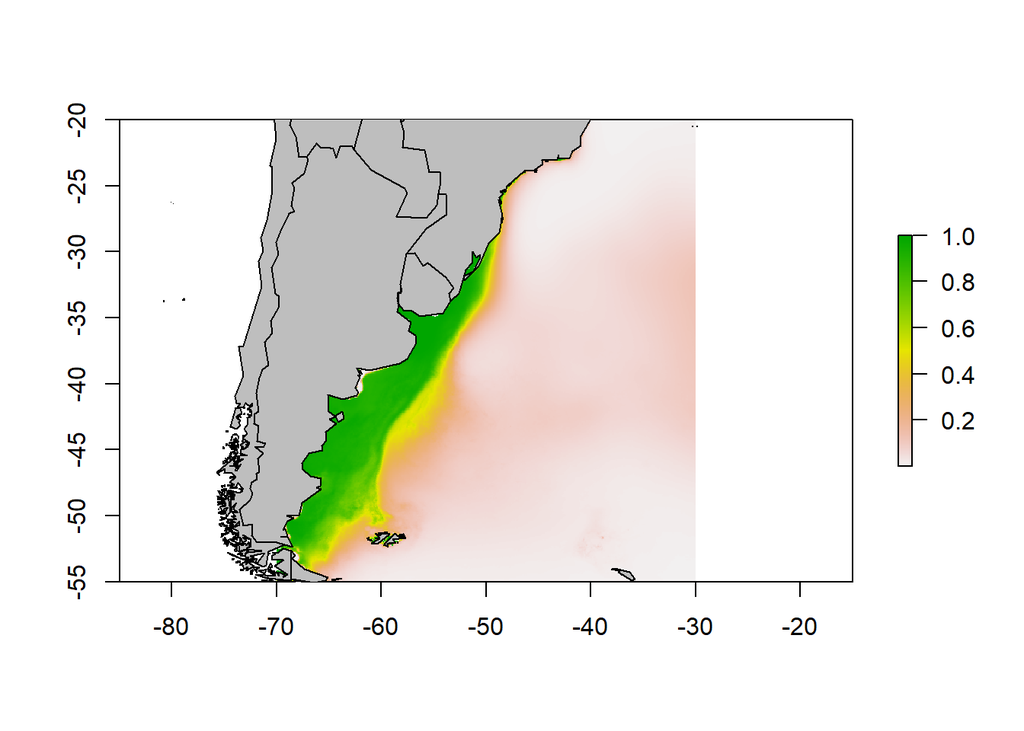

```r
pglm<-predict(predictors2,m1,type='response')

par(mfrow=c(1,1))#map prediction
plot(pglm)
plot(wrld_simpl, axes=TRUE,add=T,col="grey")
```

# 9 Model evaluation

Model evaluation is needed to verify how good the prediction is. The easier way is to see the correlation among the predicted and the observed occurrence:

```r
coords<-as.data.frame(cbind(sdmdata$x,sdmdata$y))
pp<-extract(pglm,coords)
pp<-as.data.frame(pp)
sdmdata<-cbind(sdmdata,pp)
sdmdata<-na.omit(sdmdata)
cor(sdmdata$pp,sdmdata$pb,method="spearman")
```

```
## [1] 0.7616233
```

In this case is about 0.76 that is quite good.

A common procedure to evaluate the prediction is the cross-validation. This process consists in split randomly the dataset in two main sub-sets, a training dataset (that usually includes the 70-80% of the observations) and the validation dataset (which includes the remaining 30-20%). Then the training dataset is used to run the model again and find the relationship between the species occurrence and the environmental variables, while the validation dataset is used to verify how much of the predicted presence and absences were really observed. This procedure is repeated multiple times and results are averaged over the different random subsets. Here we use the sample() function to generate these subsets and we use the proportions of 80-20%.

```r
set.seed(600)
samp <- sample(nrow(sdmdata), round(0.80 * nrow(sdmdata)))
traindata <- sdmdata[samp,]
testdata <- sdmdata[-samp,]
```

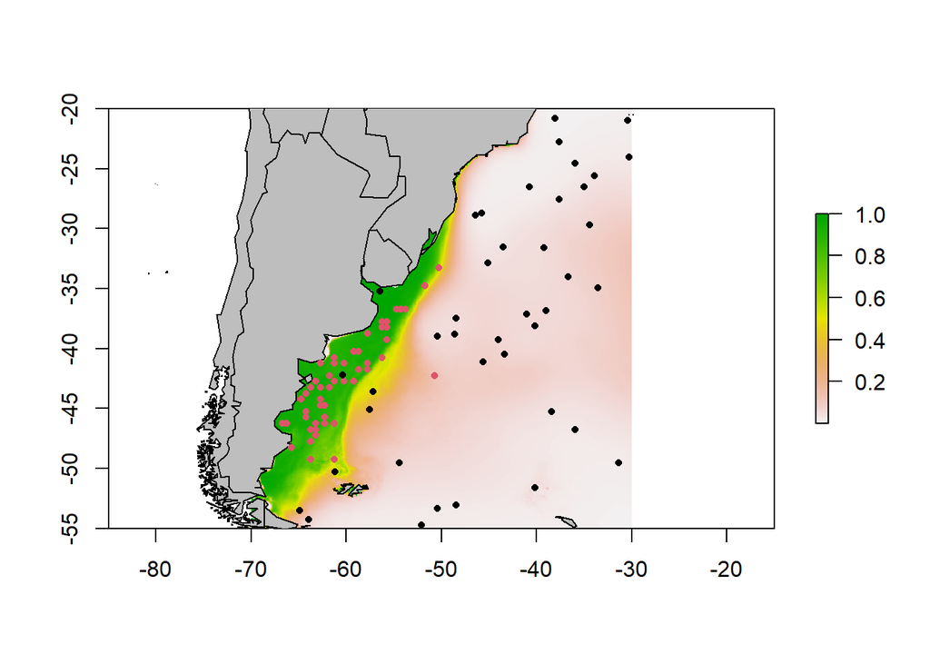

```r
m<- glm(pb ~ calcite+chlomean+nitrate+ph+salinity, data=sdmdata,family="binomial")
pglm1<-predict(predictors2,m,type='response')
plot(pglm1)
plot(wrld_simpl, add=TRUE, col="grey")
points(testdata$x,testdata$y,col=testdata$pb+1, pch=16,cex=.70)
```

Different measures can be used to evaluate the quality of a prediction. Many measures for evaluating models based on presence-absence or presence-only data are threshold dependent. That means that a threshold must be set first. Predicted values above that threshold indicate a prediction of presence, and values below the threshold indicate absence. Some measures emphasize the weight of false absences; others give more weight to false presences.

Much used statistics that are threshold independent are the correlation coefficient and the Area Under the Receiver Operator Curve (generally further abbreviated to AUC). AUC is a measure of rank-correlation. In unbiased data, a high AUC indicates that sites with high-predicted suitability values tend to be areas of known presence and locations with lower model prediction values tend to be areas where the species is not known to be present (absent or a random point). AUC score of 0.5 means that the model is as good as a random guess. Here we illustrate the computation of these measure using the evaluate() function:

```r
eglm <- dismo::evaluate(testdata[testdata==1,], testdata[testdata==0,], m);eglm
```

```
## class          : ModelEvaluation
## n presences    : 50
## n absences     : 41
## AUC            : 0.9619512
## cor            : 0.6771779
## max TPR+TNR at : 0.1591739
```

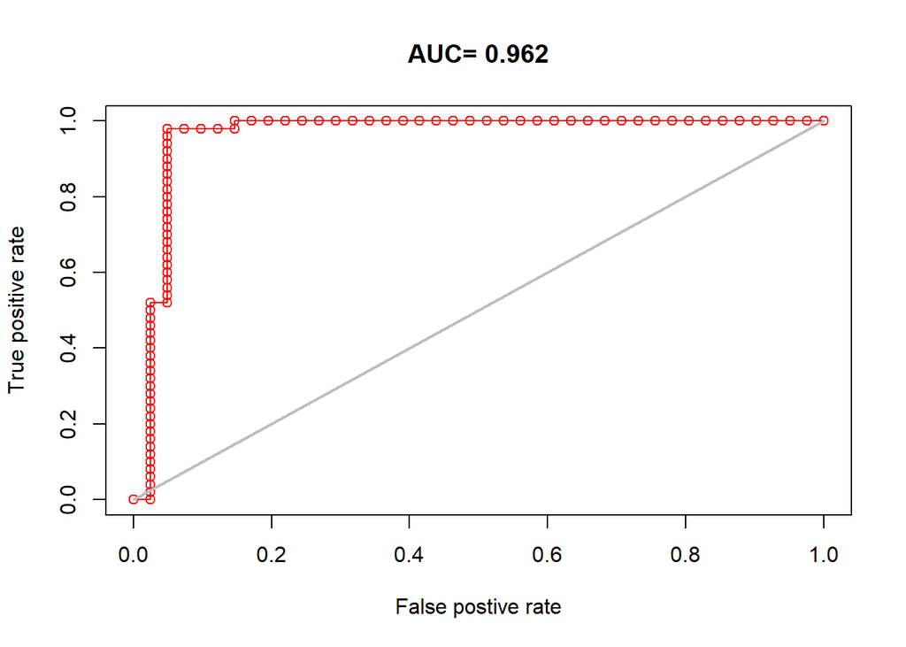

```r
plot(eglm, "ROC")
```

We can also compute the True Skill Statistic values (TSS) indicator. It deals with sensitivity and specificity, values ranging from − 1 to + 1, where + 1 indicates perfect agreement, scores ranging from 0.6 to 0.9 specify fair to good model performance, and 0 represents a random fit.

```r
TSSglm <- mean(eglm@TPR+eglm@TNR-1);TSSglm
```

```
## [1] 0.4517545
```

We can compute the threshold using the threshold() function in R:

```r
tr <- threshold(eglm,"spec_sens");tr
```

```
## [1] 0.1591739
```

Using the find threshold we can plot a binary map only with presence and absence and not probabilities:

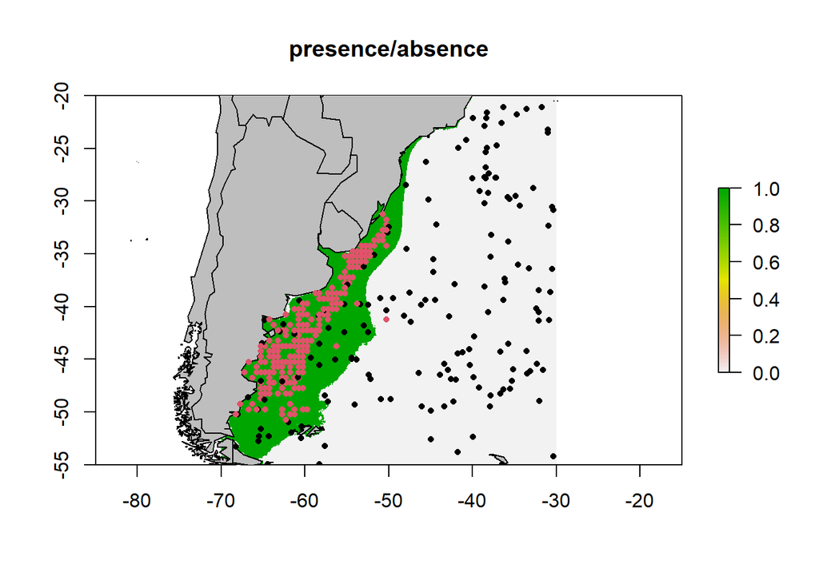

```r
plot(pglm1 > tr, main = "presence/absence")
plot(wrld_simpl, add=TRUE, col= "grey")
points(traindata$x,traindata$y, col =traindata$pb+1, pch=16, cex=.70)
```

## 9.1 Spatial autocorrelation

A common problem in the model that not takes into account the spatial component is the spatial autocorrelation. Let’s verify if our model and predictions have this problem. The easiest way to evaluate this assumption is to plot the model residuals by their spatial coordinates. We would expect to see some spatial pattern in the residuals if we have not accounted for spatial correlation. We use the bubble() plot function:

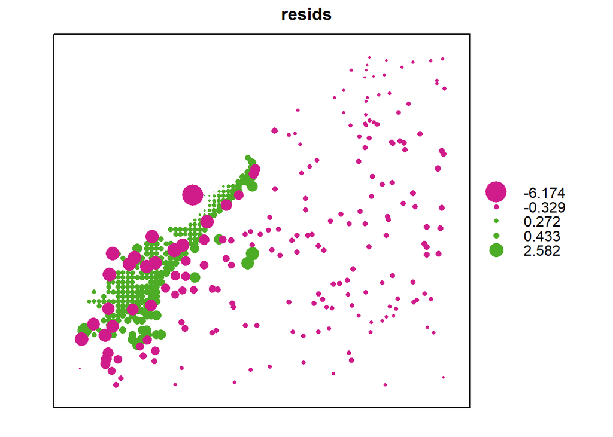

```r
dat<-data.frame(coords, resids=resid(m1))
colnames(dat)<-c("x","y","resids")
coordinates(dat)<-c('x','y');
bubble(dat, zcol='resids')
```

A nice feature of the bubble function is that it colors codes the residuals based on positive and negative values and sets the size of the points in proportion to the magnitude. An examination of the plot shows a clear residual pattern with longitude such that smaller values are seen towards the east. The bubble plot provides a qualitative means of evaluating spatial correlation We can also apply a statistical test to verify if there is spatial autocorrelation.

The Moran’s I is a measure of spatial autocorrelation–how related the values of a variable are based on the locations where they were measured. To calculate Moran’s I, we will need to generate a matrix of distance weights. Using the latitude and longitude values:

```r
nb <- dnearneigh(as.matrix(coords), 1,8);nb
```

```
## Neighbour list object:
## Number of regions: 456
## Number of nonzero links: 60524
## Percentage nonzero weights: 29.10703
## Average number of links: 132.7281
```

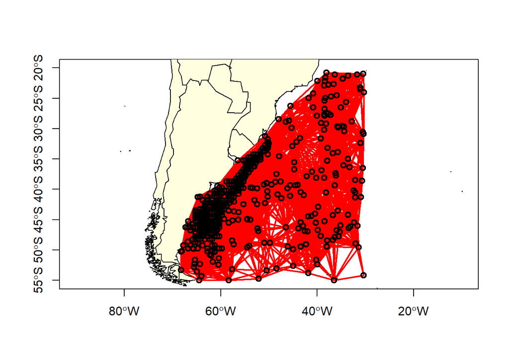

```r
plot(wrld_simpl, xlim=c(-70,-30), ylim=c(-55,-20), axes=TRUE,col="light yellow")
plot(nb, coords, col='red', lwd=2, add=TRUE)
```

```r
listw <- nb2listw(nb,style = "S")#turns neighbourhood object into a weighted list
```

Here the style “S” compute the variance stabilization (Tiefelsdorf et al. 1999) You can also use:

W = row standardized (rows sum to 1), Emphasizes weakly connected points B = binary (0/1), Emphasizes strongly connected points C = global standardized (all links sum to n), Emphasizes strongly connected points

The null hypothesis of this test is that there is no spatial autocorrelation. Then with p-values less than (0.05) the null hypothesis has to be rejected:

```r
MoranI <- moran.test(residuals(m1), listw=listw, randomisation=FALSE);
MoranI
```

```
##
##  Moran I test under normality
##
## data:  residuals(m1)
## weights: listw
##
## Moran I statistic standard deviate = 9.5352, p-value < 2.2e-16
## alternative hypothesis: greater
## sample estimates:
## Moran I statistic       Expectation          Variance
##      4.486834e-02     -2.197802e-03      2.436467e-05
```

We can conclude that there is spatial autocorrelation.